# TidyTuesday Projects - Week 19

Gustavo

2022-12-25

# 1 New York Times Best Selling Books

This dataset is from the tidytuesday project week 19 and is about the best selling books on new york times. The process done here is based on Julia Silge’s notebook found [here](https://juliasilge.com/blog/nyt-bestsellers/) Here is a glimpse of the data:

```r
# Loading libraries
library(tidyverse)

# Loading data
nyt_titles <- readr::read_tsv('https://raw.githubusercontent.com/rfordatascience/tidytuesday/master/data/2022/2022-05-10/nyt_titles.tsv')

# Glimpse function
glimpse(nyt_titles)
```

```
## Rows: 7,431
## Columns: 8
## $ id          <dbl> 0, 1, 10, 100, 1000, 1001, 1002, 1003, 1004, 1005, 1006, 1…
## $ title       <chr> "\"H\" IS FOR HOMICIDE", "\"I\" IS FOR INNOCENT", "''G'' I…
## $ author      <chr> "Sue Grafton", "Sue Grafton", "Sue Grafton", "W. Bruce Cam…
## $ year        <dbl> 1991, 1992, 1990, 2012, 2006, 2016, 1985, 1994, 2002, 1999…
## $ total_weeks <dbl> 15, 11, 6, 1, 1, 3, 16, 5, 4, 1, 3, 2, 11, 6, 9, 8, 1, 1, …
## $ first_week  <date> 1991-05-05, 1992-04-26, 1990-05-06, 2012-05-27, 2006-02-1…
## $ debut_rank  <dbl> 1, 14, 4, 3, 11, 1, 9, 7, 7, 12, 13, 5, 12, 2, 11, 13, 2, …
## $ best_rank   <dbl> 2, 2, 8, 14, 14, 7, 2, 10, 12, 17, 13, 13, 8, 5, 5, 11, 4,…
```

Here we can see that we have the book id, title, author, year and total weeks it stayed as a ‘best-seller’ book on NYT.

# 2 Exploratory Data Analysis

Distribution of the total weeks a book stays as a ‘best-seller’ in NYT:

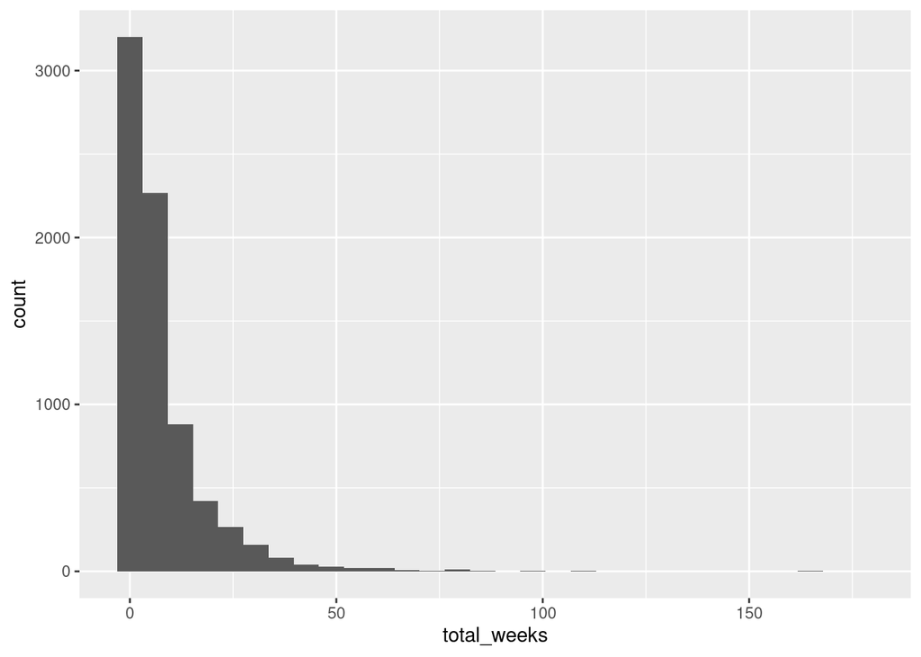

```r
nyt_titles %>%
  ggplot(aes(total_weeks))+
  geom_histogram()
```

Obviously is has a exponential distribution, as it gets harder and harder to stay a best selling book. The metrics of total weeks variable can be found below:

```r
summary(nyt_titles$total_weeks)
```

```
##    Min. 1st Qu.  Median    Mean 3rd Qu.    Max.
##   1.000   2.000   4.000   8.126  10.000 178.000
```

Let’s see the books who stayed the most as a best-seller.

```r
nyt_titles %>%
  filter(total_weeks >= 100) %>%
  arrange(desc(total_weeks)) %>%
  select(author, title, total_weeks, year) %>%
  top_n(10)
```

```
## # A tibble: 10 × 4
##    author              title                              total_weeks  year
##    <chr>               <chr>                                    <dbl> <dbl>
##  1 Dr. Seuss           OH, THE PLACES YOU'LL GO!                  178  1990
##  2 James Redfield      THE CELESTINE PROPHECY                     165  1994
##  3 Dan Brown           THE DA VINCI CODE                          165  2003
##  4 Robert James Waller THE BRIDGES OF MADISON COUNTY              164  1992
##  5 Anthony Doerr       ALL THE LIGHT WE CANNOT SEE                132  2014
##  6 Delia Owens         WHERE THE CRAWDADS SING                    114  2018
##  7 Patrick Dennis      AUNTIE MAME                                112  1955
##  8 Kathryn Stockett    THE HELP                                   108  2009
##  9 Allen Drury         ADVISE AND CONSENT                         102  1959
## 10 Mitch Albom         THE FIVE PEOPLE YOU MEET IN HEAVEN         100  2003
```

Let’s see what authors stayed did the most selling with their books!

```r
nyt_titles %>%
  group_by(author) %>%
  summarise(n = n(),
            median_total_weeks = median(total_weeks)) %>%
  arrange(-(n))
```

```
## # A tibble: 2,206 × 3
##    author                 n median_total_weeks
##    <chr>              <int>              <dbl>
##  1 Danielle Steel       116                5.5
##  2 Stuart Woods          63                2
##  3 Stephen King          54               15
##  4 Robert B. Parker      47                4
##  5 John Sandford         44                5
##  6 David Baldacci        42               10
##  7 Dean Koontz           40                5.5
##  8 Mary Higgins Clark    40                9
##  9 Sandra Brown          40                4
## 10 Nora Roberts          38                5
## # … with 2,196 more rows
```

Danielle Steel, Stuart Woods and Stephen King dominates the pool. Also, notice that the n distribution is probably exponential too.

# 3 Build the model

Let’s begin the modelling process, by dividing our training and testing groups. But first we convert the total_weeks variable into two categories:

- long
- short based on the logical condition `if_else(total_weeks > 4, true, false)`

```r
library(tidymodels)

set.seed(123)
book_split <- nyt_titles %>%
  transmute(author,
            total_weeks = if_else(total_weeks > 4, "long", "short")) %>%
  na.omit() %>%
  initial_split(strata = total_weeks)

# Separating test and training groups
books_train <- training(book_split)
books_test <- testing(book_split)

# Doing cross-validation
book_folds <- vfold_cv(books_train, strata = total_weeks)
book_folds
```

```
## #  10-fold cross-validation using stratification
## # A tibble: 10 × 2
##    splits             id
##    <list>             <chr>
##  1 <split [5012/558]> Fold01
##  2 <split [5013/557]> Fold02
##  3 <split [5013/557]> Fold03
##  4 <split [5013/557]> Fold04
##  5 <split [5013/557]> Fold05
##  6 <split [5013/557]> Fold06
##  7 <split [5013/557]> Fold07
##  8 <split [5013/557]> Fold08
##  9 <split [5013/557]> Fold09
## 10 <split [5014/556]> Fold10
```

After categorizing the total_weeks variable, we do the training and test group separation using it as a stratification variable.

```r
books_train %>% count(total_weeks)
```

```
## # A tibble: 2 × 2
##   total_weeks     n
##   <chr>       <int>
## 1 long         2721
## 2 short        2849
```

Next, lets build a workflow with an SVM classification model and tokenization of the authors names. What is wordpiece tokenization? I’m not a text processing expert, so I’m going to just skip any explanations and let the professionals handle it. More can be found [here](https://huggingface.co/docs/transformers/tokenizer_summary#wordpiece).

```r
library(textrecipes)

# Creating the specification of the model
svm_spec <- svm_linear(mode = "classification")

# Creating the recipe for pre-processing the data
books_recipe <- recipe(total_weeks ~ author, data = books_train) %>%
  step_tokenize_wordpiece(author, max_chars = 10) %>%
  step_tokenfilter(author, max_tokens = 100) %>%
  step_tf(author) %>%
  step_normalize(all_numeric_predictors())

# Just to take a glimpse
prep(books_recipe) %>% bake(new_data = NULL) %>% glimpse()
```

```
## Rows: 5,570
## Columns: 101
## $ total_weeks         <fct> long, long, long, long, long, long, long, long, lo…
## $ tf_author_.         <dbl> -0.3243985, -0.3243985, -0.3243985, -0.3243985, -0…
## $ `tf_author_'`       <dbl> -0.08715687, -0.08715687, -0.08715687, -0.08715687…
## $ `tf_author_[UNK]`   <dbl> -0.1419488, -0.1419488, -0.1419488, -0.1419488, -0…
## $ `tf_author_##a`     <dbl> -0.09419984, -0.09419984, -0.09419984, -0.09419984…
## $ `tf_author_##ac`    <dbl> -0.07836144, -0.07836144, -0.07836144, -0.07836144…
## $ `tf_author_##ci`    <dbl> -0.0771935, -0.0771935, -0.0771935, -0.0771935, -0…
## $ `tf_author_##e`     <dbl> -0.1406038, -0.1406038, -0.1406038, -0.1406038, -0…
## $ `tf_author_##er`    <dbl> -0.1458252, -0.1458252, -0.1458252, -0.1458252, -0…
## $ `tf_author_##es`    <dbl> -0.08064783, -0.08064783, -0.08064783, -0.08064783…
## $ `tf_author_##ford`  <dbl> -0.08396368, -0.08396368, -0.08396368, -0.08396368…
## $ `tf_author_##in`    <dbl> -0.07951265, -0.07951265, -0.07951265, -0.07951265…
## $ `tf_author_##l`     <dbl> -0.08064783, -0.08064783, -0.08064783, -0.08064783…
```

[output cut: 88 more lines]

Now we just need to finish the workflow:

```r
book_wf <- workflow(preprocessor = books_recipe, spec = svm_spec)
book_wf
```

```
## ══ Workflow ════════════════════════════════════════════════════════════════════
## Preprocessor: Recipe
## Model: svm_linear()
##
## ── Preprocessor ────────────────────────────────────────────────────────────────
## 4 Recipe Steps
##
## • step_tokenize_wordpiece()
## • step_tokenfilter()
## • step_tf()
## • step_normalize()
##
## ── Model ───────────────────────────────────────────────────────────────────────
## Linear Support Vector Machine Model Specification (classification)
##
## Computational engine: LiblineaR
```

# 4 Evaluate and finalize model

Now what we need to do is to specify the metrics and fit the resamples of training data.

```r
# Do paralel processing
doParallel::registerDoParallel()

# Register the metrics we want to evaluate
set.seed(123)
book_metrics <- metric_set(sens, accuracy, spec)
book_rs <- fit_resamples(book_wf, resamples = book_folds, metrics = book_metrics)

# We now collect the metrics
collect_metrics(book_rs)
```

```
## # A tibble: 3 × 6
##   .metric  .estimator  mean     n std_err .config
##   <chr>    <chr>      <dbl> <int>   <dbl> <chr>
## 1 accuracy binary     0.601    10 0.00662 Preprocessor1_Model1
## 2 sens     binary     0.423    10 0.0104  Preprocessor1_Model1
## 3 spec     binary     0.771    10 0.00943 Preprocessor1_Model1
```

Now we just need to do a final fit into the **training data** and test it into the testing data. For this, we use the `function last_fit()`

```r
book_last_fit <- last_fit(book_wf, split = book_split, metrics = book_metrics)
book_lf_metrics <- collect_metrics(book_last_fit)

# Seeing the confusion matrix
collect_predictions(book_last_fit) %>%
  conf_mat(.pred_class, total_weeks)
```

```
##           Truth
## Prediction long short
##      long   342   565
##      short  229   721
```

If we think our model is already ok, we can extract ou final model with the function `extract_workflow()`:

```r
# Extracting the final model
final_svm_model <- extract_workflow(book_last_fit)

# Testing into (possible) new data
augment(final_svm_model, new_data = slice_sample(books_test, n = 2))
```

```
## # A tibble: 2 × 3
##   author         total_weeks .pred_class
##   <chr>          <chr>       <fct>
## 1 Donna Leon     short       short
## 2 Rita Mae Brown short       short
```

We can algo evaluate what are most important coefficients since this is a Linear Support Vector Machine:

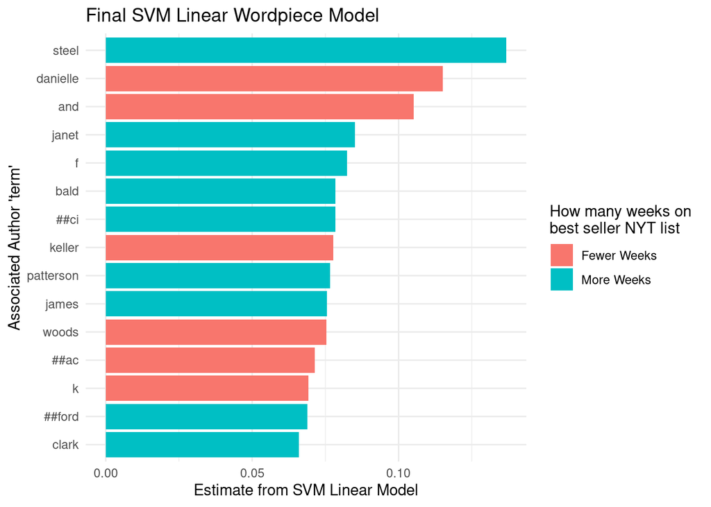

```r
tidy(final_svm_model) %>%
  slice_max(abs(estimate), n = 15) %>%
  mutate(term = str_remove_all(term, "tf_author_")) %>%
  mutate(term = fct_reorder(term, abs(estimate))) %>%
  ggplot(aes(x = abs(estimate), y = term, fill = estimate > 0))+
  geom_col()+
  scale_fill_discrete(labels = c("Fewer Weeks", "More Weeks"))+
  labs(fill = "How many weeks on \nbest seller NYT list",
       y = "Associated Author 'term'",
       x = "Estimate from SVM Linear Model",
       title = "Final SVM Linear Wordpiece Model")+
  theme_minimal()
```

# 5 About

```r
sessioninfo::package_info()
```

```
##  package        * version    date (UTC) lib source
##  assertthat       0.2.1      2019-03-21 [1] CRAN (R 4.2.1)
##  backports        1.4.1      2021-12-13 [1] CRAN (R 4.2.1)
##  bit              4.0.5      2022-11-15 [1] CRAN (R 4.2.2)
##  bit64            4.0.5      2020-08-30 [1] CRAN (R 4.2.1)
##  broom          * 1.0.2      2022-12-15 [1] CRAN (R 4.2.2)
##  bslib            0.4.2      2022-12-16 [1] CRAN (R 4.2.2)
##  cachem           1.0.6      2021-08-19 [1] CRAN (R 4.2.2)
##  cellranger       1.1.0      2016-07-27 [1] CRAN (R 4.2.1)
##  class            7.3-20     2022-01-13 [4] CRAN (R 4.2.0)
##  cli              3.5.0      2022-12-20 [1] CRAN (R 4.2.2)
##  codetools        0.2-18     2020-11-04 [4] CRAN (R 4.2.0)
##  colorspace       2.0-3      2022-02-21 [1] CRAN (R 4.2.1)
##  crayon           1.5.2      2022-09-29 [1] CRAN (R 4.2.2)
##  curl             4.3.3      2022-10-06 [1] CRAN (R 4.2.2)
##  DBI              1.1.3      2022-06-18 [1] CRAN (R 4.2.1)
##  dbplyr           2.2.1      2022-06-27 [1] CRAN (R 4.2.1)
##  dials          * 1.1.0      2022-11-04 [1] CRAN (R 4.2.2)
##  DiceDesign       1.9        2021-02-13 [1] CRAN (R 4.2.2)
##  digest           0.6.31     2022-12-11 [1] CRAN (R 4.2.2)
##  doParallel       1.0.17     2022-02-07 [1] CRAN (R 4.2.2)
##  dplyr          * 1.0.10     2022-09-01 [1] CRAN (R 4.2.2)
##  ellipsis         0.3.2      2021-04-29 [1] CRAN (R 4.2.1)
##  evaluate         0.19       2022-12-13 [1] CRAN (R 4.2.2)
##  fansi            1.0.3      2022-03-24 [1] CRAN (R 4.2.1)
##  farver           2.1.1      2022-07-06 [1] CRAN (R 4.2.1)
##  fastmap          1.1.0      2021-01-25 [1] CRAN (R 4.2.1)
##  fastmatch        1.1-3      2021-07-23 [1] CRAN (R 4.2.2)
##  forcats        * 0.5.2      2022-08-19 [1] CRAN (R 4.2.2)
##  foreach          1.5.2      2022-02-02 [1] CRAN (R 4.2.2)
##  fs               1.5.2      2021-12-08 [1] CRAN (R 4.2.1)
##  furrr            0.3.1      2022-08-15 [1] CRAN (R 4.2.2)
##  future           1.30.0     2022-12-16 [1] CRAN (R 4.2.2)
##  future.apply     1.10.0     2022-11-05 [1] CRAN (R 4.2.2)
##  gargle           1.2.1      2022-09-08 [1] CRAN (R 4.2.2)
##  generics         0.1.3      2022-07-05 [1] CRAN (R 4.2.1)
##  ggplot2        * 3.4.0      2022-11-04 [1] CRAN (R 4.2.2)
##  globals          0.16.2     2022-11-21 [1] CRAN (R 4.2.2)
##  glue             1.6.2      2022-02-24 [1] CRAN (R 4.2.1)
##  googledrive      2.0.0      2021-07-08 [1] CRAN (R 4.2.1)
```

[output cut: 69 more lines]

```
##  vroom            1.6.0      2022-09-30 [1] CRAN (R 4.2.2)
##  withr            2.5.0      2022-03-03 [1] CRAN (R 4.2.1)
##  wordpiece      * 2.1.3      2022-03-03 [1] CRAN (R 4.2.2)
##  wordpiece.data   2.0.0      2022-03-03 [1] CRAN (R 4.2.2)
##  workflows      * 1.1.2      2022-11-16 [1] CRAN (R 4.2.2)
##  workflowsets   * 1.0.0      2022-07-12 [1] CRAN (R 4.2.2)
##  xfun             0.36       2022-12-21 [1] CRAN (R 4.2.2)
##  xml2             1.3.3      2021-11-30 [1] CRAN (R 4.2.1)
##  yaml             2.3.6      2022-10-18 [1] CRAN (R 4.2.2)
##  yardstick      * 1.1.0      2022-09-07 [1] CRAN (R 4.2.2)
##
##  [1] /home/gustavo/R/x86_64-pc-linux-gnu-library/4.2
##  [2] /usr/local/lib/R/site-library
##  [3] /usr/lib/R/site-library
##  [4] /usr/lib/R/library
```